# SAR11 Protein Comparison

2023-05-09

# Project Information

SAR11 is a group of small, carbon-oxidizing bacteria that reach a global estimated population size of 2.4×1028 cells-approximately 25% of all plankton. They play a key role in the ocean’s environment.

The goal of this comparative genomics project is to find presence and absence of SAR11 genomes. The genomes of interest were obtained from NCBI database.

# Additional Information:

Goal for the final figure.

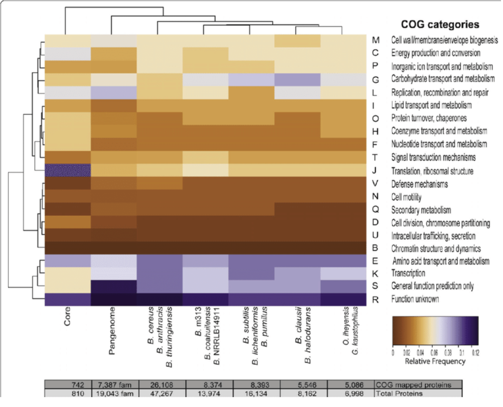

RPubs Link for Euryarchaeota: https://rpubs.com/sggarcia6/1042560

# BLAST Comparison of 45 (HTCC1062) to others.

Having the comparison of 45 to 95 into a CSV file.

```r
# Read out the blast file into csv
bltabl1 <- read.csv("../output/45-95_blastp.tab", sep = '\t', header = FALSE)


#Extract columns desired
 bltabl1_2.0 <- bltabl1[, c("V1", "V2", "V11", "V12")]

#Make into dataframe

bltabl1_2.0_df <- data_frame(bltabl1_2.0)
colnames(bltabl1_2.0_df) <- c("Query", "Database", "Eval", "Score")
```

Having the comparison of 45 to GCA_012276695.1(also known as NP1) into a CSV file.

```r
# Read out the blast file into csv
bltabl2 <- read.csv("../output/45-NP1_blastp.tab", sep = '\t', header = FALSE)


#Extract columns desired
 bltabl2_2.0 <- bltabl2[, c("V1", "V2", "V11", "V12")]

#Make into dataframe

bltabl2_2.0_df <- data_frame(bltabl2_2.0)

colnames(bltabl2_2.0_df) <- c("Query", "Database", "Eval", "Score")
```

Having the comparison of 45 to GCA_000155895 into a CSV file. (HTCC7211)

```r
# Read out the blast file into csv
bltabl3 <- read.csv("../output/bigblast-01/GCA_000155895.1_45_blastp.tab", sep = '\t', header = FALSE)


#Extract columns desired
 bltabl3_2.0 <- bltabl3[, c("V1", "V2", "V11", "V12")]

#Make into dataframe

bltabl3_2.0_df <- data_frame(bltabl3_2.0)

colnames(bltabl3_2.0_df) <- c("Query", "Database", "Eval", "Score")
```

Having the comparison of 45 to GCA_002101295 into a CSV file. (Alphaproteobacteria RS40)

```r
# Read out the blast file into csv
bltabl4 <- read.csv("../output/bigblast-01/GCA_002101295.1_45_blastp.tab", sep = '\t', header = FALSE)


#Extract columns desired
 bltabl4_2.0 <- bltabl4[, c("V1", "V2", "V11", "V12")]

#Make into dataframe

bltabl4_2.0_df <- data_frame(bltabl4_2.0)

colnames(bltabl4_2.0_df) <- c("Query", "Database", "Eval", "Score")
```

Having the comparison of 45 to GCA_028230015.1 into a CSV file. (AM-375-I16)

```r
# Read out the blast file into csv
bltabl5 <- read.csv("../output/bigblast-01/GCA_028230015.1_45_blastp.tab", sep = '\t', header = FALSE)


#Extract columns desired
 bltabl5_2.0 <- bltabl5[, c("V1", "V2", "V11", "V12")]

#Make into dataframe

bltabl5_2.0_df <- data_frame(bltabl5_2.0)

colnames(bltabl5_2.0_df) <- c("Query", "Database", "Eval", "Score")
```

Having the comparison of 45 to GCA_028229715.1 into a CSV file. (AM-375-K20)

```r
# Read out the blast file into csv
bltabl6 <- read.csv("../output/bigblast-01/GCA_028229715.1_45_blastp.tab", sep = '\t', header = FALSE)


#Extract columns desired
 bltabl6_2.0 <- bltabl6[, c("V1", "V2", "V11", "V12")]

#Make into dataframe

bltabl6_2.0_df <- data_frame(bltabl6_2.0)

colnames(bltabl6_2.0_df) <- c("Query", "Database", "Eval", "Score")
```

# Reading the file from 45 protein to CSV file.

```r
spgo <- read.csv("../output/45protein.tab", sep = '\t', header = TRUE)
colnames(spgo) <- c("Database", "Protein", "Coding_Sequence")
```

# Tables for each comparison

45 to 95

```r
# Join the data frames
joined1_df <- left_join(bltabl1_2.0_df, spgo, by = c("Database" = "Database")) %>%
  mutate(Organism = "sar95")

# You may print the table with kable
#kable(head(joined1_df, n = 10), caption = "Joined data frame with kable formatting (first 10 rows)")

#Scrollable tables
datatable(head(joined1_df), options = list(scrollX = TRUE, scrollY = "400px", scrollCollapse = TRUE, paging = FALSE))
```

|  | Query | Database | Eval | Score | Protein | Coding_Sequence | Organism |
| --- | --- | --- | --- | --- | --- | --- | --- |
| 1 | QIZ20180.1 | AAZ22016.1 | 0 | 571 | ABC transporter [Candidatus Pelagibacter ubique HTCC1062] | MNIFKKTILSVLASLLLIGNVYADKIKIGTEGAYPPWNSKDASGALIGFEVELAEELCKI…… | sar95 |
| 2 | QIZ20181.1 | AAZ22015.1 | 5.16e-165 | 450 | ABC transporter [Candidatus Pelagibacter ubique HTCC1062] | MDLLSFGKTGWGDELFYATLMTIAVAVTAMLIGFLFSLIFTPLKLSNNKFLNFIGNTYTT…… | sar95 |
| 3 | QIZ20182.1 | AAZ22014.1 | 3.42e-161 | 440 | octopine-like transport system permease protein oocM [Candidatus Pelagibacter ubique HTCC1062] | MDFDLMITSLPKLLSAAVITLKLLSASLIIGLFIGFLFAVLRLNKNPFINKFAYGYSYLF…… | sar95 |
| 4 | QIZ20183.1 | AAZ22013.1 | 2.2e-86 | 243 | conserved hypothetical protein [Candidatus Pelagibacter ubique HTCC1062] | MNKILVEVSVGELLDKISILEIKQEKIKDPEKLKFINDEHSILKNQLDSNVKSDEKLNTLFQSLKDINAKLWVIEDDKRLCEKNSDFTEKFIKLSRDVHFLNDDRAKIKLEMNNHTGSKIKEIKEYTSY | sar95 |
| 5 | QIZ20184.1 | AAZ22012.1 | 0 | 584 | heptosyltransferase family protein [Candidatus Pelagibacter ubique HTCC1062] | MSNILVIKHGSLGDIAQACGAIQDISENHPEDQIHILTTKPYFELFRKNPFVHNVILDKR…… | sar95 |
| 6 | QIZ20185.1 | AAZ22011.1 | 0 | 531 | possible AbrB protein [Candidatus Pelagibacter ubique HTCC1062] | MIKEYLLMKNSSIQFNSFNIKELFSKKFLLVILISIPSAIVADYFNIPLAWMLGPMLAVS…… | sar95 |

45 to GCA_012276695.1

```r
# Join the data frames
joined2_df <- left_join(bltabl2_2.0_df, spgo, by = c("Database" = "Database")) %>%
  mutate(Organism = "NP1")

# You may print the table with kable
#kable(head(joined2_df, n = 10), caption = "Joined data frame with kable formatting (first 10 rows)")

#Scrollable tables
datatable(head(joined2_df), options = list(scrollX = TRUE, scrollY = "400px", scrollCollapse = TRUE, paging = FALSE))
```

|  | Query | Database | Eval | Score | Protein | Coding_Sequence | Organism |
| --- | --- | --- | --- | --- | --- | --- | --- |
| 1 | QIZ20180.1 | AAZ22016.1 | 0 | 571 | ABC transporter [Candidatus Pelagibacter ubique HTCC1062] | MNIFKKTILSVLASLLLIGNVYADKIKIGTEGAYPPWNSKDASGALIGFEVELAEELCKI…… | NP1 |
| 2 | QIZ20181.1 | AAZ22015.1 | 5.16e-165 | 450 | ABC transporter [Candidatus Pelagibacter ubique HTCC1062] | MDLLSFGKTGWGDELFYATLMTIAVAVTAMLIGFLFSLIFTPLKLSNNKFLNFIGNTYTT…… | NP1 |
| 3 | QIZ20182.1 | AAZ22014.1 | 3.42e-161 | 440 | octopine-like transport system permease protein oocM [Candidatus Pelagibacter ubique HTCC1062] | MDFDLMITSLPKLLSAAVITLKLLSASLIIGLFIGFLFAVLRLNKNPFINKFAYGYSYLF…… | NP1 |
| 4 | QIZ20183.1 | AAZ22013.1 | 2.2e-86 | 243 | conserved hypothetical protein [Candidatus Pelagibacter ubique HTCC1062] | MNKILVEVSVGELLDKISILEIKQEKIKDPEKLKFINDEHSILKNQLDSNVKSDEKLNTLFQSLKDINAKLWVIEDDKRLCEKNSDFTEKFIKLSRDVHFLNDDRAKIKLEMNNHTGSKIKEIKEYTSY | NP1 |
| 5 | QIZ20184.1 | AAZ22012.1 | 0 | 584 | heptosyltransferase family protein [Candidatus Pelagibacter ubique HTCC1062] | MSNILVIKHGSLGDIAQACGAIQDISENHPEDQIHILTTKPYFELFRKNPFVHNVILDKR…… | NP1 |
| 6 | QIZ20185.1 | AAZ22011.1 | 0 | 531 | possible AbrB protein [Candidatus Pelagibacter ubique HTCC1062] | MIKEYLLMKNSSIQFNSFNIKELFSKKFLLVILISIPSAIVADYFNIPLAWMLGPMLAVS…… | NP1 |

45 to GCA_000155895.1

```r
# Join the data frames
joined3_df <- left_join(bltabl3_2.0_df, spgo, by = c("Database" = "Database")) %>%
  mutate(Organism = "HTCC711")

# You may print the table with kable
#kable(head(joined3_df, n = 10), caption = "Joined data frame with kable formatting (first 10 rows)")

#Scrollable tables
datatable(head(joined3_df), options = list(scrollX = TRUE, scrollY = "400px", scrollCollapse = TRUE, paging = FALSE))
```

|  | Query | Database | Eval | Score | Protein | Coding_Sequence | Organism |
| --- | --- | --- | --- | --- | --- | --- | --- |
| 1 | EDZ59680.1 | AAZ21533.1 | 6.31e-90 | 268 | Predicted permease YjgP/YjgQ family protein [Candidatus Pelagibacter ubique HTCC1062] | MKTYIKFLINLFNISLLKIFITFFIIILITNILEQIEFFKNIDLSFFYLFFLSLLNTPSV…… | HTCC711 |
| 2 | EDZ59681.1 | AAZ21142.1 | 0 | 612 | Conserved hypothetical protein [Candidatus Pelagibacter ubique HTCC1062] | MILNNSFSLIKKKIRHFYLNSYLYNKKITPSSIELLEYQPSPSLLDGLIKYDKKKINIEN…… | HTCC711 |
| 3 | EDZ59682.1 | AAZ21001.1 | 0 | 1169 | oligopeptidase B [Candidatus Pelagibacter ubique HTCC1062] | MKIPHLKKKSEIKTCHNISWEDDYSWIHQDDILEVLKDSKKLNPEVRKYLEEENSYTDFH…… | HTCC711 |
| 4 | EDZ59683.1 | AAZ21482.1 | 1.14e-152 | 422 | LamB/YcsF family [Candidatus Pelagibacter ubique HTCC1062] | MLYSRLKSMEININCDLGEKSKFHSIKNDPELLNIVNSANIACGYHAGDEKTMEMVIQIS…… | HTCC711 |
| 5 | EDZ59684.1 | AAZ21759.1 | 0 | 709 | nitrogen assimilation regulatory protein ntrX [Candidatus Pelagibacter ubique HTCC1062] | MSTEILIIDDNADIRNIINDLIIEAGYKTRLAANYNQALNEIDKKLPDVAIIDVKLDKSD…… | HTCC711 |
| 6 | EDZ59685.1 | AAZ20941.1 | 1.74e-46 | 138 | H+-transporting two-sector ATPase (subunit C) [Candidatus Pelagibacter ubique HTCC1062] | MELEAAKMIGAGLAAIALAGAGVGIGIIFGNYLSGAMRNPSAAQKQFPNLLLGFALAEATGLFGLVVALIILFAF | HTCC711 |

45 to GCA_002101295.1

```r
# Join the data frames
joined4_df <- left_join(bltabl4_2.0_df, spgo, by = c("Database" = "Database")) %>%
  mutate(Organism = "RS40")

#You may print the table with kable
#kable(head(joined4_df, n = 10), caption = "Joined data frame with kable formatting (first 10 rows)")

#Scrollable tables
datatable(head(joined4_df), options = list(scrollX = TRUE, scrollY = "400px", scrollCollapse = TRUE, paging = FALSE))
```

|  | Query | Database | Eval | Score | Protein | Coding_Sequence | Organism |
| --- | --- | --- | --- | --- | --- | --- | --- |
| 1 | ARJ48461.1 | AAZ21771.1 | 2.95e-40 | 122 | unknown protein [Candidatus Pelagibacter ubique HTCC1062] | MLIKKYLKWISTALVLTGILLTNLNIYPINIYFHGLGVIGWTIAGFISKDKAILTNFGLQIPLFLIGIYKIIF | RS40 |
| 2 | ARJ48462.1 | AAZ21980.1 | 2.87e-109 | 309 | phosphate regulatory protein [Candidatus Pelagibacter ubique HTCC1062] | MSVSIHIVEDEQPIITLVKYNLEKEGYKVSSSDNGNEGIEDIKKLFPDLVLLDWMLPDFS…… | RS40 |
| 3 | ARJ48463.1 | AAZ21981.1 | 1.95e-111 | 315 | phosphate transport regulon regulator PhoU [Candidatus Pelagibacter ubique HTCC1062] | MSDITHIVKSYEDELQSLNDNLIKMGSLVEAQLTDSMEAIIKVDKEAAENIIKNDEKINE…… | RS40 |
| 4 | ARJ48464.1 | AAZ21982.1 | 2.69e-161 | 443 | phosphate ABC transporter [Candidatus Pelagibacter ubique HTCC1062] | MKNNKIKIKSSNLNVHYGEKQALFDVDLDIYDKEVTALIGPSGCGKSTFIRCINRMNDVI…… | RS40 |
| 5 | ARJ48465.1 | AAZ21984.1 | 0 | 658 | ABC transporter [Candidatus Pelagibacter ubique HTCC1062] | MNIIILLLVTIFSYLSFLYGRSRIRKITSTQSIKINALPNYYGYYLALWCALPALIILLF…… | RS40 |
| 6 | ARJ48466.1 | AAZ21985.1 | 0 | 560 | phosphate ABC transporter [Candidatus Pelagibacter ubique HTCC1062] | MKNVKIILSILTVMLFASNVQARDQIRIVGSSTVYPYATVVAENFGKTGKFKTPVIESTG…… | RS40 |

45 to GCA_028230015.1

```r
# Join the data frames
joined5_df <- left_join(bltabl5_2.0_df, spgo, by = c("Database" = "Database")) %>%
  mutate(Organism = "AM-375-I16")

# You may print the table with kable
#kable(head(joined5_df, n = 10), caption = "Joined data frame with kable formatting (first 10 rows)")

#Scrollable tables
datatable(head(joined5_df), options = list(scrollX = TRUE, scrollY = "400px", scrollCollapse = TRUE, paging = FALSE))
```

|  | Query | Database | Eval | Score | Protein | Coding_Sequence | Organism |
| --- | --- | --- | --- | --- | --- | --- | --- |
| 1 | MDB2692762.1 | AAZ22118.1 | 8.82e-106 | 297 | GlxC protein [Candidatus Pelagibacter ubique HTCC1062] | MNLDLNKKKLREINQLLQNVGREKNNRSFQILNPQGQHAICAGLKDDIEVSIKGHTGYYC…… | AM-375-I16 |
| 2 | MDB2692763.1 | AAZ22117.1 | 0 | 596 | Glutamine amidotransferase-like protein glxB [Candidatus Pelagibacter ubique HTCC1062] | MCGIVGIYLKTKKYEKDLGKFLSGMLDGMATRGPDSAGFAIYTKQNKNKFKYSICLNQLT…… | AM-375-I16 |
| 3 | MDB2692764.1 | AAZ22116.1 | 3.87e-32 | 100 | unknown membrane protein [Candidatus Pelagibacter ubique HTCC1062] | MNENNQENQRPSKMRGVVFPKAKYGVIAAIIIIVVGNIFYYKEFLLSLIK | AM-375-I16 |
| 4 | MDB2692765.1 | AAZ22115.1 | 5.37e-51 | 149 | unknown membrane protein [Candidatus Pelagibacter ubique HTCC1062] | MATVTNWIDHLSAEEVVGAIYPGAGSTETLLVILGVVFWIGWHVITAKSESEKLSRLAKKRHGANDHKSNITDW | AM-375-I16 |
| 5 | MDB2692766.1 | AAZ22114.1 | 0 | 926 | ammonium transporter [Candidatus Pelagibacter ubique HTCC1062] | MDDQLGALTVIFTEFYYWVTVVLMFLIHVGFCMYEVGASRYKHHQHTLMKNTMVIPLVTV…… | AM-375-I16 |
| 6 | MDB2692767.1 | AAZ22113.1 | 1.28e-98 | 275 | unknown [Candidatus Pelagibacter ubique HTCC1062] | MVKKKTKIKVKKENLGGKSKETAREKMIGQHIGYRYDVNLLPDYKKITPFLKKYIEAMGWDDLNWLEDIHMGYEEDRPAVFCRNANGWVTIPKSIKLPNNQQDRDMIARELLVKFQMSKKHPLVDLKKAYLKF | AM-375-I16 |

45 to GCA_028229715.1

```r
# Join the data frames
joined6_df <- left_join(bltabl6_2.0_df, spgo, by = c("Database" = "Database")) %>%
  mutate(Organism = "AM-375-K20")

# You may print the table with kable
#kable(head(joined6_df, n = 10), caption = "Joined data frame with kable formatting (first 10 rows)")

#Scrollable tables
datatable(head(joined6_df), options = list(scrollX = TRUE, scrollY = "400px", scrollCollapse = TRUE, paging = FALSE))
```

|  | Query | Database | Eval | Score | Protein | Coding_Sequence | Organism |
| --- | --- | --- | --- | --- | --- | --- | --- |
| 1 | MDB2696308.1 | AAZ21621.1 | 6.83e-132 | 371 | epoxide hydrolase [Candidatus Pelagibacter ubique HTCC1062] | MIKPFKLDIPDKVLQEIYTKVKNYPWHEMPDDGGWKYGSNLDYMKEISNYWIKDFDWRKH…… | AM-375-K20 |
| 2 | MDB2696309.1 | AAZ21620.1 | 0 | 527 | Phosphate acetyltransferase (Phosphotransacetylase) [Candidatus Pelagibacter ubique HTCC1062] | MLSVQDAVNENLITPIFIGNKKEILKCAEDLKWDISKFEIIDEPIENNTAAIAAKLASQD…… | AM-375-K20 |
| 3 | MDB2696310.1 | AAZ21619.1 | 0 | 881 | histidinol dehydrogenase 2 [Candidatus Pelagibacter ubique HTCC1062] | MAITYLKKSPKTSSTDDTKTTGIVQDLLKNIETTKEQGCIDLTKKFDKYDGEIIVSKERI…… | AM-375-K20 |
| 4 | MDB2696311.1 | AAZ21618.1 | 2.75e-137 | 378 | Lysine efflux pump [Candidatus Pelagibacter ubique HTCC1062] | MDYLILGFLTGLSLILAIGAQNIFVIEQGLKKQYIFIVCLICSISDFLLIFLGIFLFQYL…… | AM-375-K20 |
| 5 | MDB2696312.1 | AAZ21617.1 | 0 | 1004 | Glycine betaine/L-proline transport system permease protein [Candidatus Pelagibacter ubique HTCC1062] | MDNKANRNPSRDELITDFVKSNPDYYIKEFKKIGSKPTYSFSFNLFAFIFGPIWFGMRNI…… | AM-375-K20 |
| 6 | MDB2696313.1 | AAZ21616.1 | 0 | 694 | glycine betaine/L-proline transport ATP-binding protein [Candidatus Pelagibacter ubique HTCC1062] | MDSAIEIKNVWKIFGNTSVEALNAIQNNRISKQEALEKYNSVIGVSDVSFDVKKGEIFCV…… | AM-375-K20 |